# Introduction to ELVAR

Alok K Maity and Andrew E Teschendorff

2023-02-22

#### Package

ELVAR 0.1.5

# Contents

> **Abstract: ELVAR is an R-package for differential abundance (DA) testing of cell-types in single-cell RNA-Seq data. It implements an Extended Louvain clustering Algorithm (EVA) that takes cell attribute information into acccount when inferring cellular communities from the cell-cell nearest neighbour graph. By taking cell attribute information into account, improved community detection is possible, which improves the power to detect DA-shifts of cell-types in relation to disease risk factors or disease itself.**

# 1 Motivation and Background

The ability to quantify changes in cell-type abundance associated with different biological conditions is important to improve our understanding of disease risk factors and disease itself (Dann et al. (2022)). In principle, single-cell RNA-Seq (scRNA-Seq) data offers the opportunity to measure such differential abundance (DA) patterns. However, in practice this can be complicated due to technical and biological factors. One issue is that scRNA-Seq assays are influenced by cell-size which is known to vary between cell-types. As a result, inference of DA is best done by comparison of cellular states within a cell-type (e.g. different macrophage polarization states, or different CD4+ T-cell activation states), because cell-size is unlikely to confound such comparisons between states. Another challenge arises due to technical batch effects, which could confound observed cell numbers. To address this, it is necessary to obtain sample replicates for the same biological condition, for instance, sampling multiple mice at young and old ages. By measuring replicates one can also capture the biological variability. A third challenge is that we are often interested in inferring DA-patterns in relation to subtle phenotypes such as aging or exposure to risk factors, which means that the shifts in DA can be of small effect size and challenging to discern.

In order to reliably quantify DA of cell-types/cell-states in relation to some biological condition (e.g. age/disease state), we developed a pipeline for DA-testing called ELVAR (Extended LouVain Algorithmin R) (Maity and Teschendorff (2022)). ELVAR consists of two steps. First, it uses an Extended Louvain Algorithm called EVA (Citraro and Rossetti (2020)) to infer communities in a manner that takes cell-attribute information into account, for instance a biological condition such as age or disease stage. By incorporating cell-attribute information into account we are not only considering the topological relation of cells in the cell-cell neighborhood graph but also their attributes (e.g. age) when clustering cells. This helps denoise data and improves the inference of communities that are more relevant for downstream DA-testing. Once the cell clusters are identified, the procedure identifies communities enriched for the attribute used in the clustering. As mentioned, this is usually a biological condition such as age of disease state. The cells from these enriched communities are then extracted and negative binomial regressions (NBRs) are used to assess if counts of specific cell-types or cell-states change in relation to the biological condition. This NBR-step uses sample replicate information into account. We stress that the reason for doing clustering of cells at all (as opposed to directly running NBRs between cell-counts and the biological condition) is to ensure that the cells representing the same condition and cell-type, and which are being used in the inference, do indeed represent the same cellular state, a fundamental assumption underlying any DA-analysis.

In this tutorial vignette we will illustrate the application of ELVAR (note that ELVAR here refers to the whole algorithmic pipeline for DA-analysis, and not just the EVA algorithm) to aging to identify a subtle shift in the proportion of naive to activated Cd4+ T-cells in lung tissue, using data from the Tabula Muris Senis (Consortium (2020)).

# 2 Tutorial Example

In order to run the tutorial, we must first load in the necessary libraries and scRNA-Seq dataset:

## 2.1 Loading required packages

```r
library(ELVAR)
```

```r
library(Seurat)
library(Matrix)
library(dplyr)
library(igraph)
library(MASS)
library(ggplot2)
data(lungCD4Tinfo);
print(dim(lungCD4Tsel.m));
```

```
## [1] 20138   537
```

The scRNA-Seq dataset is a 10X lung-tissue dataset of Cd4+ T-cells from the Tabula Muris Senis (Consortium (2020)). The data consists of 537 Cd4+ T-cells from 11 mice representing 5 different age groups (1m, 3m, 18m, 21m and 30m, m=months). The phenotype information of the cells is in the `phenoCD4T.lv` object, with the age of cells annotated with 0 (1m), 1 (3m), 2 (18m), 3 (21m) and 5 (30m). Because no mice were sampled at age 24 months, we don't have a "4". In addition to age, we have also annotated the cells according to their naive(1)/mature(0) status, using the known Lef1 marker expression to indicate naive Cd4+ T-cells. Building a table of age-group vs activation status

```r
table(phenoCD4T.lv$age,phenoCD4T.lv$naive)
```

```
##
##      0  1
##   0 81 62
##   1 60 62
##   2 45 22
##   3 83 24
##   5 82 16
```

we can see that there is clear trend towards less naive Cd4+ T-cells with increased age. However, we can't be sure that the cells in each category are really in the same cellular state, as defined by the state-manifold. Hence, we need to first derive the state-manifold, and then infer relevant cell clusters.

## 2.2 Deriving the state-manifold

In order to derive the state-manifold, i.e. the cell-cell nearest neighbor graph, we will make use of the popular Seurat algorithm to first process and explore the data:

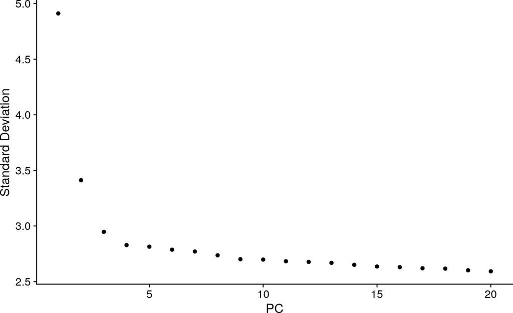

```r
seu.o <- CreateSeuratObject(as.matrix(lungCD4Tsel.m),project = "seuratLungCD4T")
# assign phenotypes
seu.o$age <- phenoCD4T.lv$age
seu.o$naive <- phenoCD4T.lv$naive
seu.o$mouse <- phenoCD4T.lv$mouse
seu.o <- FindVariableFeatures(seu.o, selection.method = "vst",verbose=FALSE);
seu.o <- ScaleData(seu.o,verbose=FALSE);
seu.o <- RunPCA(seu.o,verbose=FALSE);
ElbowPlot(seu.o);
```

We now proceed to build the state-manifold and to visualize the data:

```r
seu.o <- FindNeighbors(seu.o, dims = 1:8, k.param=20,verbose=FALSE);
seu.o <- FindClusters(seu.o, resolution = 0.1,verbose=FALSE);
seu.o <- RunTSNE(seu.o, dims = 1:10,verbose=FALSE);
```

Of note, we have chosen the cell-cell graph to have a connectivity of 20, i.e each cell is connected to another 19 (this is because Seurat takes self-loops into account). Next, we visualise the data:

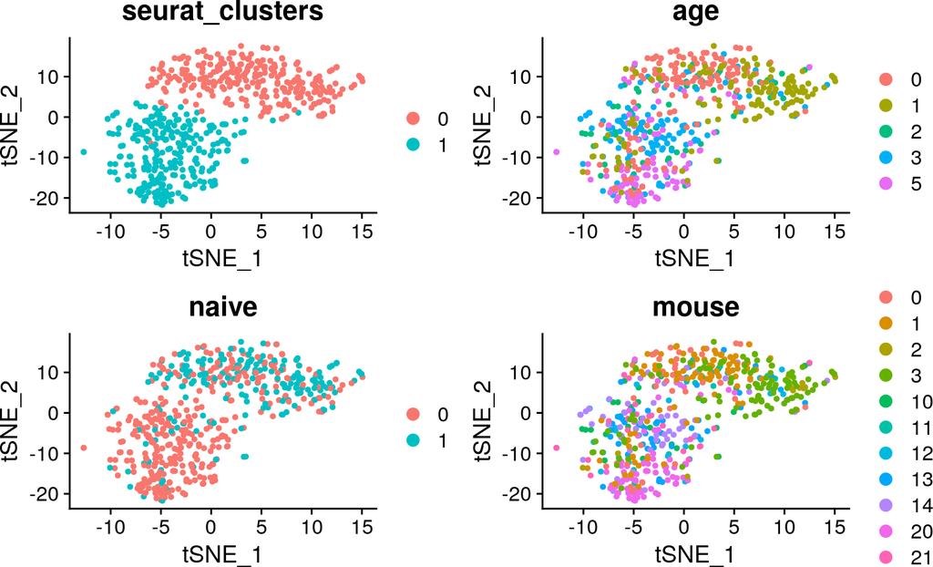

```r
DimPlot(seu.o, reduction = "tsne", group.by = c("seurat_clusters", "age","naive", "mouse"));
```

We can observe how there are two main clusters that correlate with age and activation status. We now proceed to extract the state-manifold in preparation for EVA-clustering:

```r
adj.m <- as.matrix(seu.o@graphs$RNA_nn)
diag(adj.m) <- 0
gr.o <- graph.adjacency(adj.m,mode="undirected");
vertexN.v <- names(V(gr.o));
vertex_attr(gr.o,name="age") <- seu.o@meta.data$age;
comp.o <- components(gr.o);
print(is.connected(gr.o));
```

```
## [1] TRUE
```

In the above, we have assigned the age of the cells as an attribute to the cell-cell nearest neighbor graph, since later we are going to search for clusters that are enriched for specific age-groups. In order to run the EVA-algorithm it is important that the graph is connected, which is the case here.

## 2.3 Inferring cellular communities with EVA

We are now ready to infer the cellular communities within the state-manifold. We do this using the EVA algorithm, which as mentioned earlier takes cell attribute information into account when inferring clusters.

```r
eva.o <- Eva_partitions(gr.o, resolution=1, threshold=0.0000001, alpha= 0.8, Vattr.name= "age");
```

```
## [1] 15520
## [1] 0.03816468 0.18962507 0.99979309
## [1] 0.03109099 0.37515867 0.99227343
## [1] -0.005362157  0.373227279  0.986053582
## [1] 15520
## [1] 0.1323276 0.4804919 0.8889525
## [1] 0.0007357071 0.4883852977 0.8878987424
## [1] 0.0157352 0.4899485 0.9071769
## [1] -0.01108819  0.48731153  0.89397595
## [1] -0.05084525
```

Before inspecting the output it is worth explaining what the arguments to this functions mean. The `resolution` parameter controls the average size of the communities. Community size decreases with increasing resolution value. In general, the default value of 1 is acceptable for all applications considered here. The `threshold` parameter is the tolerance threshold for the optimization function. In general, the default value is ok for most circumstances and does not need to be altered. The `alpha` parameter is the most important parameter as it controls the relative importance of purity (defined by how homogeneous the inferred communities are in relation to the cell attribute of interest) and modularity (the Louvain modularity compares the edge density of the communities to that of a null distribution obtained by randomising edges keeping the degrees fixed). The parameter `alpha` varies between 0 (favours high modularity) and 1 (favours high purity), with `alpha=0` in effect being the standard Louvain algorithm. Of note, in the above expression we have chosen `alpha=0.8`. To understand why we chose this value, we note that normally we would run EVA a large number of times for many different choices of alpha, to then select the optimal alpha-value based on specific quantitative criteria. Briefly, the optimal alpha value is one that leads to improved purity over standard Louvain without much degradation in the modularity. It is also important that at the optimal alpha-value the number of inferred clusters also departs from the Louvain number. In order to aid the user select an optimal alpha-value we provide a dedicated function called `SelOptAlpha`. This function requires as input the number of EVA clusters, the purity and modularity for a fairly large number of runs and for a range of different alpha values. We recommend around 100 runs and alpha to range from 0.1 to 0.9 in steps of 0.1. To save time, we here import precomputed cluster numbers, modularities and purities, as well as the number of clusters inferred using the standard Louvain algorithm:

```r
data(purmodInfo);
print(dim(nC.m));
```

```
## [1] 100   9
```

```r
print(dim(pur.m));
```

```
## [1] 100   9
```

```r
print(dim(mod.m));
```

```
## [1] 100   9
```

```r
print(paste("Number of clusters inferred with Louvain=",nc0,sep=""));
```

```
## [1] "Number of clusters inferred with Louvain=6"
```

We now plot the number of clusters (normalized relative to Louvain), purity and modularity as a function of alpha:

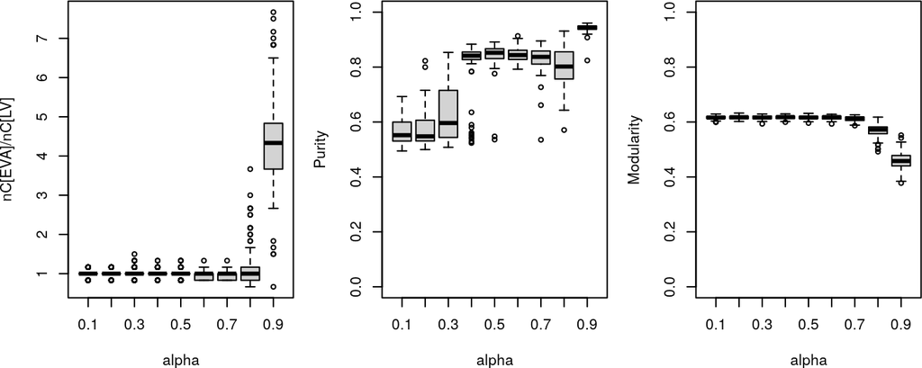

```r
par(mfrow=c(1,3));
par(mar=c(4,4,2,1));
boxplot(nC.m/nc0 ~ col(nC.m/nc0),ylab="nC[EVA]/nC[LV]",xlab="alpha",names=colnames(pur.m));
boxplot(pur.m ~ col(pur.m),ylim=c(0,1),ylab="Purity",xlab="alpha",names=colnames(pur.m));
boxplot(mod.m ~ col(mod.m),ylim=c(0,1),ylab="Modularity",xlab="alpha",names=colnames(pur.m));
```

We now apply the `SelOptAlpha` function:

```r
selAlpha.o <- SelOptAlpha(nC.m,nc0,pur.m,mod.m,alpha.v=seq(0.1,0.9,0.1));
print(selAlpha.o)
```

```
## $aM
## [1] 0.8
##
## $aP
## [1] 0.4
##
## $aC
## [1] 0.8
```

Now, we are ready to inspect the output of the EVA/ELVAR algorithm run at this optimal alpha=0.8 value. Because the inferred communities can display some variation depending on the run, we load in a precomputed typical output. In practice one would run the algorithm a significant number of times (100 times say) to ensure that results are robust. First, we overlay the measured purity and modularity values:

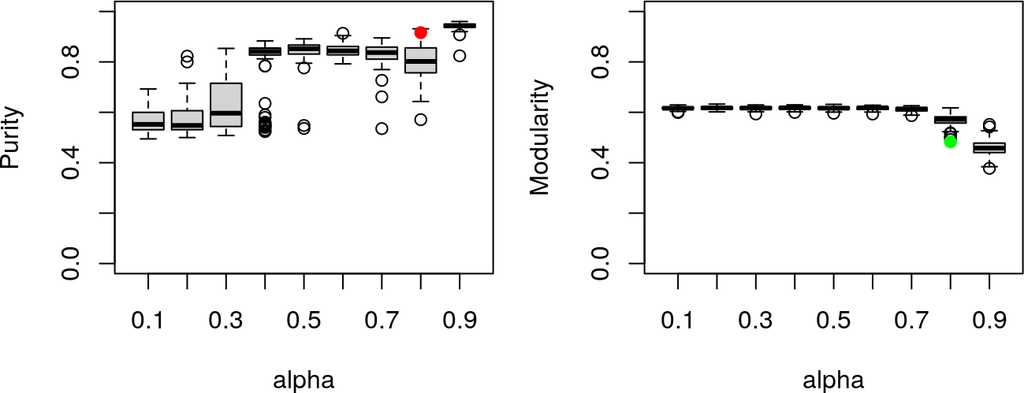

```r
data(evaout);
par(mfrow=c(1,2));
par(mar=c(4,4,2,1));
boxplot(pur.m ~ col(pur.m),ylim=c(0,1),ylab="Purity",xlab="alpha",names=colnames(pur.m));
points(x=8,y=eva.o$Pur,pch=21,col="red",bg="red");
boxplot(mod.m ~ col(mod.m),ylim=c(0,1),ylab="Modularity",xlab="alpha",names=colnames(pur.m));
points(x=8,y=eva.o$Mod,pch=21,col="green",bg="green");
```

This shows that the given run falls within the distribution of modularity and purity values for `alpha=0.8`, as required. The next step is to explore which communities are enriched for which age-groups. Since age information was used as an attribute in the clustering, the expectation is that a reasonable number of clusters should be enriched for various age-groups. First, let us look at the distribution of cells per inferred cluster and age-group:

```r
table(eva.o$CommunityMembers,seu.o@meta.data$age)
```

```
##
##       0  1  2  3  5
##   1   0  0  1  0  0
##   2  49 12 16  7  3
##   3   3  9 16 47 21
##   4  25 17 18 39 68
##   5  58 15  7  8  1
##   6   2  0  0  0  2
##   7   0  0  3  0  0
##   8   1  0  0  0  0
##   9   5 69  6  6  2
##   10  0  0  0  0  1
```

To assess which clusters are overenriched in specific age-groups we derive a P-value of significance using a Binomial test, subsequently selecting for each age-group the significant clusters using a Bonferroni significance threshold. If for a given age-group there are multiple enriched clusters, we will merge the cells from these clusters and age-group together. These steps can be accomplished using the `ProcessEVA` function:

```r
sigcl.o <- ProcessEVA(eva.o,seu.o,attrName="age");
print(sigcl.o$pvalEnr);
```

```
##
##                 0            1            2            3            5
##   1  2.662942e-01 2.271881e-01 1.247672e-01 1.992551e-01 1.824953e-01
##   2  1.332678e-09 9.732698e-01 3.948655e-02 9.979479e-01 9.999662e-01
##   3  1.000000e+00 9.994300e-01 8.568477e-02 4.650790e-11 1.467903e-01
##   4  9.997685e-01 9.999782e-01 7.005529e-01 1.153830e-01 3.806711e-12
##   5  6.309022e-15 8.860920e-01 8.799728e-01 9.957900e-01 9.999997e-01
##   6  6.044868e-02 6.433065e-01 4.131943e-01 5.888724e-01 2.098412e-02
##   7  6.050285e-01 5.384472e-01 1.942234e-03 4.865685e-01 4.536503e-01
##   8  2.662942e-01 2.271881e-01 1.247672e-01 1.992551e-01 1.824953e-01
##   9  9.999996e-01 2.235221e-29 9.336138e-01 9.994308e-01 9.999958e-01
##   10 2.662942e-01 2.271881e-01 1.247672e-01 1.992551e-01 1.824953e-01
```

Thus, we can see that for specific age-groups, certain clusters are strongly enriched. To check which clusters have been selected for each age-group:

```r
print(sigcl.o$sigClust);
```

```
## [[1]]
## [1] "2" "5"
##
## [[2]]
## [1] "9"
##
## [[3]]
## character(0)
##
## [[4]]
## [1] "3"
##
## [[5]]
## [1] "4"
```

We can see that for the first age-group, two clusters (clusters 2 and 5) have been selected, for the third age-group no enriched cluster was found, and for the two older age-groups, there is one unique enriched cluster. The next step is to perform a differential abundance analysis. Specifically, we are interested in knowing whether the relative propotion of naive to mature Cd4+ T-cells changes with age. Before we do so, it is valuable to check how many sample replicates (in our case these are mouse replicates) contribute to enriched cell-clusters from each age-group:

```r
table(seu.o@meta.data$age[unlist(sigcl.o$cellsMrg)],seu.o@meta.data$mouse[unlist(sigcl.o$cellsMrg)]);
```

```
##
##      0  1  2  3 13 14 20 21
##   0 34 73  0  0  0  0  0  0
##   1  0  0  9 60  0  0  0  0
##   3  0  0  0  0 20 27  0  0
##   5  0  0  0  0  0  0 62  6
```

We can see that for each age-group (labeled along rows), there are two mouse replicates contributing cells. This therefore allows us to assess inter-subject variability when assessing DA.

## 2.4 Differential abundance (DA) analysis

Before running the DA-analysis, it is useful to first retabulate the distribution of naive vs mature Cd4+ T-cells as a function of age-group, but now restricting to the high-confidence cells, i.e. the cells defining enriched clusters, which hence define valid cell-states:

```r
tab.m <- table(seu.o@meta.data$age[unlist(sigcl.o$cellsMrg)],seu.o@meta.data$naive[unlist(sigcl.o$cellsMrg)]);
tab.m;
```

```
##
##      0  1
##   0 50 57
##   1 25 44
##   3 38  9
##   5 61  7
```

```r
chisq.test(tab.m);
```

```
##
##  Pearson's Chi-squared test
##
## data:  tab.m
## X-squared = 57.507, df = 3, p-value = 2.003e-12
```

We can see that there is a clear skew towards reduced naive Cd4+ T-cell fraction with age. However, this analysis ignores sample replicate information, and so could be biased. In order to perform the DA-analysis taking replicate information into account, we can run the function `DoDA` as follows:

```r
da.o <- DoDA(seu.o,sigcl.o,varDA="naive",varREP="mouse");
print(da.o$stat);
```

```
##       Wald(z)      Wald(P)    LRT(z)       LRT(P)
## CS0  4.235300 2.282473e-05  6.302402 1.465335e-10
## CS1 -4.439609 9.012226e-06 -6.176327 3.280509e-10
```

In the above, in the function `DoDA` we had to specify which is the cell-state variable that we want to perform DA for, as well as the variable defining the sample replicates. In our case, the cell-state variable is the naive/mature status of the cells, whereas the sample replicate refers to the different mice. The function `DoDA` performs the negative binomial regressions, and the output statistics (Wald and LRT) show that whilst the mature/activated (CS0) Cd4+ T-cell fraction increases with age, that the corresponding naive (CS1) Cd4+ T-cell fraction decreases. The P-values are highly significant and having anchored the analysis on cell-states defined on the state-manifold and having taken inter-subject variability into account, we can be much more confident of the result we obtained earlier using the non-rigorous approach.

# References

Citraro, S., and G. Rossetti. 2020. “Identifying and Exploiting Homogeneous Communities in Labeled Networks.” *Applied Network Science* 5 (55).

Consortium, Tabula Muris. 2020. “A Single-Cell Transcriptomic Atlas Characterizes Ageing Tissues in the Mouse.” *Nature* 583 (7817): 590–95.

Dann, E., N. C. Henderson, S. A. Teichmann, M. D. Morgan, and J. C. Marioni. 2022. “Differential Abundance Testing on Single-Cell Data Using K-Nearest Neighbor Graphs.” *Nat Biotech* 40 (2).

Maity, A. K., and A. E. Teschendorff. 2022. “Cell-Attribute Aware Community Detection Improves Differential Abundance Testing from Single-Cell Rna-Seq Data.” *Submitted*.